# Exploring the Role of Sex and Genetic Variants in Alzheimer’s Pathophysiology: Insights from Amyloid PET Imaging

#### KIN_V 482E Final Project by Nerea Eva Lopez and Maée Paroz

#### 01.12.2024

## Introduction

Alzheimer's disease (AD) is a neurodegenerative disorder responsible for the majority of dementia cases worldwide [1]. While its biological mechanisms remain incompletely understood, research continues to uncover potential risk factors and biomarkers, such as specific genetic variants and amyloid accumulation [2].

Alzheimer's disease (AD) is marked by the presence of extracellular amyloid plaques and intracellular neurofibrillary tangles. The prevailing model of AD pathogenesis suggests that the accumulation of Aβ (amyloid-beta) peptide triggers a cascade of downstream events, ultimately resulting in cognitive impairment [3].

Over 80 genetic regions have been linked to Alzheimer's disease. However, the condition is often influenced by a combination of multiple genes, along with lifestyle and environmental factors. Nevertheless, carrying multiple risk-associated genetic variants can increase the likelihood of developing Alzheimer's, highlighting the need to better understand the role of these genetic variants. [4]

AD is marked by pronounced sex differences in incidence, pathophysiology and progression [5]. Certain genetic variants showed differing effects between females and males, emphasizing the need to evaluate their impact with a focus on sex and gender differences.

In 2008, the longitudinal Dallas Lifespan Brain Study began collecting extensive data to explore factors influencing cognitive preservation and decline across the adult lifespan. This rich dataset, utilized in this project, includes participants' genetic and demographic information, along with amyloid accumulation data obtained from three waves of PET imaging.

This project aims to integrate this novel multiomics data with computational tools, to investigate sex differences among carriers of risk genes and their influence on amyloid PET imaging.

## Dataset

The Dallas Lifespan Brain Study Data: https://openneuro.org/datasets/ds004856/versions/1.2.0

Sub-datasets used in this project:

- "participants.tsv" - Contains demographic and cognitive measures for each patient (e.g., age, sex, BMI).
- "Template19_Genotyping.xlsx" - Includes genotype data for each patient for four risk genes (APOE, BDNF, COMT, DRD2).
- "Template17_Amyloid.xlsx", "Template17_Amyloid_wave2.xlsx", and "Template17_Amyloid_wave3.xlsx" - Contain amyloid measurements in different brain regions, with one dataframe per wave (three time points per patient).

## Hypothesis

Throughout this project, we will be visualizing our data, to adress the following hypothesis:

- Sex interacts with specific genetic variants (e.g., APOE, BDNF, COMT, DRD2) to influence Amyloid PET data.

To test this hypothesis, we will explore the following questions:

1. What is the sex distribution among carriers of risk genes associated with Alzheimer's disease in the dataset?
2. How do different genetic variants correlate to Amyloid data?
3. How does amyloid distribution differ by sex across varying levels of genetic risk?

## Data Preprocessing

### Library Import

```python
import pandas as pd
import matplotlib.pyplot as plt
import seaborn as sns
from matplotlib import gridspec
import scipy.stats as stats
from matplotlib import cm
```

### Data Import

```python
#import the dataset participant
participant = pd.read_csv("participants.tsv", delimiter="\t")
#convert into a DataFrame
participant = pd.DataFrame(participant)

participant.sample(5)
```

|  | participant_id | AgeCog_W1 | AgeMRI_W1 | AgePETAmy_W1 | AgeCog_W2 | AgeMRI_W2 | AgePETAmy_W2 | AgePETTau_W2 | AgeCog_W3 | AgeMRI_W3 | ... | MMSE_W3 | CogW1toW2 | CogW2toW3 | CogW1toW3 | MRIW1toW2 | MRIW2toW3 | MRIW1toW3 | PETAmyW1toW2 | PETAmyW2toW3 | PETAmyW1toW3 |
| --- | --- | --- | --- | --- | --- | --- | --- | --- | --- | --- | --- | --- | --- | --- | --- | --- | --- | --- | --- | --- | --- |
| 429 | sub-841 | 49 | 50 | NaN | 53.0 | 54.0 | NaN | NaN | 59.0 | 59.0 | ... | 29.0 | 4.00 | 5.57 | 9.57 | 4.00 | 5.20 | 9.20 | NaN | NaN | NaN |
| 307 | sub-4315 | 77 | 77 | 77.0 | 79.0 | 80.0 | 80.0 | 82.0 | 84.0 | 84.0 | ... | 30.0 | 2.47 | 4.38 | 6.85 | 2.62 | 4.19 | 6.81 | 2.93 | NaN | NaN |
| 428 | sub-836 | 54 | 54 | 54.0 | NaN | NaN | NaN | NaN | NaN | NaN | ... | NaN | NaN | NaN | NaN | NaN | NaN | NaN | NaN | NaN | NaN |
| 140 | sub-1928 | 34 | 34 | 34.0 | NaN | NaN | NaN | NaN | NaN | NaN | ... | NaN | NaN | NaN | NaN | NaN | NaN | NaN | NaN | NaN | NaN |
| 238 | sub-327 | 41 | 41 | NaN | 45.0 | 45.0 | NaN | NaN | 51.0 | NaN | ... | 30.0 | 4.15 | 5.63 | 9.79 | 4.15 | NaN | NaN | NaN | NaN | NaN |

5 rows × 36 columns

This dataset contains 464 rows and 36 columns. The 36 variables include key demographic and cognitive measures such as age, gender, race, ethnicity, education level, and MMSE (Mini-Mental State Examination) scores, offering a broad view of the participant characteristics. Furthermore, the time between the different tests are listed. More information about the variables can be found in this document (https://bpb-us-e2.wpmucdn.com/sites.utdallas.edu/dist/e/1233/files/2021/10/DLBS-KTTK-06-04-21.pdf).

```python
#import the dataset genotype
genotype = pd.read_excel("Template19_Genotyping.xlsx")

genotype.sample(5)
```

|  | S# | ConstructName | ConstructNumber | Wave | HasData | NumScores | APOE112 | APOE158 | APOEGenotype | E4CarrierStatus | TotalE4Alleles | BDNF | BDNFGenotype | COMT | COMTGenotype | DRD2 | DRD2Genotype |
| --- | --- | --- | --- | --- | --- | --- | --- | --- | --- | --- | --- | --- | --- | --- | --- | --- | --- |
| 17 | 93 | Genotyping | 19 | 1 | 1 | 11 | TC | CC | e3/e4 | 1 | 1 | GG | Val/Val | GG | Val/Val | GA | Al1/Al2 |
| 37 | 153 | Genotyping | 19 | 1 | 1 | 11 | TC | CC | e3/e4 | 1 | 1 | GG | Val/Val | GG | Val/Val | GG | Al1/Al1 |
| 54 | 213 | Genotyping | 19 | 1 | 1 | 11 | TT | CC | e3/e3 | 0 | 0 | GG | Val/Val | GA | Val/Met | GA | Al1/Al2 |
| 185 | 1136 | Genotyping | 19 | 1 | 1 | 11 | TT | CC | e3/e3 | 0 | 0 | AG | Met/Met | GA | Val/Met | GA | Al1/Al2 |
| 178 | 1054 | Genotyping | 19 | 1 | 1 | 11 | TT | CT | e2/e3 | 0 | 0 | AG | Met/Met | GA | Val/Met | GA | Al1/Al2 |

The dataset genotype contains 419 rows and 16 columns. All of the genotype data was examined at the time of wave 1. 4 specific genotype data was collected. The following genotypes are associated with a higher risk of getting Alzheimer's Disease;

- APOE gene: The ε4 allele increases the risk for AD and is associated with an earlier disease onset. Having two copies of ε4 is associated with a higher risk than having one copy [4]. A previous study showed that female carriers of ε4 between the age of 65 and 75 years are more susceptible to AD than men [6].
- COMT: Catechol-O-methyltransferase (COMT) regulates dopamine levels in the prefrontal cortex which are involved in working memory and executive functioning [7]. The COMT Val/Met functional polymorphism significantly affects the enzyme activity, and is associated with some cognitive domains and psychosis in AD [8].
- BDNF: Val/Met in the brain-derived neurotrophic factor (BDNF) gene is associated with worse impact of beta-amyloid on neurodegeneration, resulting in greater AD-related cognitive impairment [9].
- DRD2: This gene encodes the D2 subtype of the dopamine receptor. The A1 allele results in a significant loss of D2 receptor density in the brain, which might have an impact on the risk of Alzheimer’s [10].

```python
#import the datasets amyloid for the three waves of the study
amyloid_w1 = pd.read_excel("Template17_Amyloid.xlsx")
amyloid_w2 = pd.read_excel("Template17_Amyloid_wave2.xlsx")
amyloid_w3 = pd.read_excel("Template17_Amyloid_wave3.xlsx")

amyloid_w1.sample(5)
```

|  | S# | ConstructName | ConstructNumber | Wave | HasData | NumScores | Amyloid | MRItoAmyloid | CaudalAnteriorCingulateCount | CaudalMiddleFrontalCount | ... | VOIPosteriorCingulateIsthmusCount | VOIAnteriorCingulateSUVR | VOIDorsolateralPrefrontalSUVR | VOILateralParietalSUVR | VOILateralTemporalSUVR | VOIOrbitofrontalSUVR | VOIPosteriorCingulateIsthmusSUVR | LateralOccipitalSUVR | PrecuneusSUVR | GlobalSUVR |
| --- | --- | --- | --- | --- | --- | --- | --- | --- | --- | --- | --- | --- | --- | --- | --- | --- | --- | --- | --- | --- | --- |
| 256 | 4540 | Amyloid PET | 17 | 1 | 1 | 59 | 1 | 0.076712 | 3220.410792 | 3169.942262 | ... | 3343.405192 | 1.079335 | 1.008460 | 0.944681 | 0.923146 | 1.111850 | 1.082492 | 0.953951 | 0.997666 | 1.012698 |
| 110 | 1600 | Amyloid PET | 17 | 1 | 1 | 59 | 1 | 0.101370 | 2710.678386 | 2839.653044 | ... | 2736.099114 | 0.912692 | 0.957870 | 1.016456 | 0.938175 | 0.941765 | 0.976616 | 1.083685 | 0.989678 | 0.977117 |
| 142 | 2054 | Amyloid PET | 17 | 1 | 1 | 59 | 1 | 0.098630 | 3933.662759 | 4004.875084 | ... | 4177.233305 | 1.703795 | 1.695133 | 1.680169 | 1.653230 | 1.648154 | 1.790029 | 1.368452 | 1.869733 | 1.676087 |
| 40 | 695 | Amyloid PET | 17 | 1 | 1 | 59 | 1 | 0.747945 | 1501.616367 | 1465.431025 | ... | 1574.652258 | 1.038150 | 0.995443 | 0.965250 | 0.971546 | 1.114514 | 1.074351 | 0.923433 | 1.035537 | 1.014778 |
| 194 | 3344 | Amyloid PET | 17 | 1 | 1 | 59 | 1 | 0.038356 | 3070.434961 | 2586.653256 | ... | 2961.319689 | 1.098623 | 0.964542 | 0.931398 | 0.913983 | 1.150525 | 1.085988 | 0.894897 | 1.058571 | 1.012316 |

5 rows × 66 columns

This dataset contains 295 rows and 66 columns. The Wave number is listed, as well as if Amyloid Data was collected (Amyloid = 1) or no Data was collected (Amyloid =3). The measurement of Amyloid data in different brain regions is reported as a total count and as Standardized Uptake Values Ratio (SUVR). The SUVR is a ratio of the tracer uptake in a target region (e.g., the cortex) to the reference region. It helps account for individual variability in tracer distribution and systemic factors. Higher SUVR indicate greater amyloid deposition, which is often seen in individuals with Alzheimer's. [11]

## Data Cleaning

### Cleaning Dataset Participant

```python
#change format of participant id to allow comparison with other datasets
participant["participant_id"] = participant["participant_id"].str.replace("sub-", "", regex=False).astype(float).astype(int)
#subject numbers as index
participant = participant.set_index("participant_id")

#select the relevant columns
relevant_column = ["AgeCog_W1", "Sex", "Race", "BMI_W1"]
participant_clean  = participant[relevant_column]

# Drop rows with NA values in any of the relevant columns
participant_clean = participant_clean.dropna()

participant_clean.head()
```

| participant_id | AgeCog_W1 | Sex | Race | BMI_W1 |
| --- | --- | --- | --- | --- |
| 1003 | 54 | m | 5 | 31.912 |
| 1007 | 73 | m | 5 | 29.950 |
| 1008 | 22 | m | 2 | 27.461 |
| 101 | 44 | f | 5 | 20.359 |
| 1011 | 70 | m | 5 | 27.800 |

### Cleaning Dataset Genotype

```python
#subject numbers as index
genotype = genotype.set_index("S#")

#select the relevant columns for answering our research questions
relevant_column = ["TotalE4Alleles","BDNFGenotype","COMTGenotype","DRD2Genotype"]
genotype_clean = genotype[relevant_column]

# Replace empty strings (" ") with Na
genotype_clean = genotype_clean.copy()
genotype_clean["BDNFGenotype"] = genotype_clean["BDNFGenotype"].replace(" ", pd.NA)
genotype_clean["COMTGenotype"] = genotype_clean["COMTGenotype"].replace(" ", pd.NA)
# Drop rows with NA values in any of the relevant columns
genotype_clean = genotype_clean.dropna()

genotype_clean.head()
```

| S# | TotalE4Alleles | BDNFGenotype | COMTGenotype | DRD2Genotype |
| --- | --- | --- | --- | --- |
| 12 | 1 | Val/Val | Val/Met | Al1/Al2 |
| 21 | 0 | Val/Val | Val/Met | Al1/Al2 |
| 26 | 0 | Val/Val | Val/Met | Al1/Al1 |
| 28 | 0 | Met/Met | Met/Met | Al1/Al2 |
| 32 | 0 | Val/Val | Met/Met | Al1/Al1 |

### Cleaning Dataset Amyloid

```python
#select the relevant columns for answering our research questions
relevant_columns=['S#', 'Wave', 'Amyloid','GlobalSUVR']

#define a function to clean the three amyloid datasets
def clean_amyloid(df):
    """
    Cleans and filters the amyloid dataset for a given wave.

    Parameters:
    df (DataFrame): The amyloid dataset for a specific wave.

    Returns:
    DataFrame: The cleaned dataset with only relevant columns and rows.
    """
    #extract relevant columns
    df=df[relevant_columns]
    #Amyloid = 1 if data exists
    df=df[df["Amyloid"]==1]
    return df

#filter amyloid dataset for relevant columns
amyloid_w1_clean = clean_amyloid(amyloid_w1)
amyloid_w2_clean = clean_amyloid(amyloid_w2)
amyloid_w3_clean = clean_amyloid(amyloid_w3)

#w2: 180 from the 295 original patients were measured
#w3: 76 from the 295 original patients were measured

#only keep data from the patients from whom data for all three waves exist
#find patients who are present in all three waves
common_patients = set(amyloid_w1_clean['S#']) & set(amyloid_w2_clean['S#']) & set(amyloid_w3_clean['S#'])

#filter the dataframes to keep only these patients
amyloid_w1_clean = amyloid_w1_clean[amyloid_w1_clean['S#'].isin(common_patients)]
amyloid_w2_clean = amyloid_w2_clean[amyloid_w2_clean['S#'].isin(common_patients)]
amyloid_w3_clean = amyloid_w3_clean[amyloid_w3_clean['S#'].isin(common_patients)]

amyloid_w1_clean.head()
```

|  | S# | Wave | Amyloid | GlobalSUVR |
| --- | --- | --- | --- | --- |
| 0 | 169 | 1 | 1 | 1.093245 |
| 1 | 178 | 1 | 1 | 0.955994 |
| 6 | 245 | 1 | 1 | 1.010939 |
| 13 | 326 | 1 | 1 | 0.994870 |
| 15 | 341 | 1 | 1 | 1.024116 |

### Fusion of Datasets

```python
def join(df1, df2, how):
    """
    Joins two DataFrames based on the specified method.

    Parameters:
        df1 (DataFrame): The first DataFrame.
        df2 (DataFrame): The second DataFrame.
        how (str): The type of join to perform.
            - 'inner': Only rows with indices present in both DataFrames are kept.
            - 'outer': All indices from both DataFrames are kept, filling missing values with NaN.
            - 'left': Keep all indices from df1 and match rows from df2 where possible.
            - 'right': Keep all indices from df2 and match rows from df1 where possible.

    Returns:
        DataFrame: The resulting joined DataFrame.
    """
    return df1.join(df2, how=how)
```

```python
#join participant and genotype based on index names
df_q1 = join(participant_clean, genotype_clean, "inner")
df_q1 = df_q1.reset_index()
df_q1.head()
```

|  | participant_id | AgeCog_W1 | Sex | Race | BMI_W1 | TotalE4Alleles | BDNFGenotype | COMTGenotype | DRD2Genotype |
| --- | --- | --- | --- | --- | --- | --- | --- | --- | --- |
| 0 | 1003 | 54 | m | 5 | 31.912 | 0 | Val/Val | Val/Met | Al1/Al2 |
| 1 | 1007 | 73 | m | 5 | 29.950 | 0 | Met/Met | Val/Met | Al1/Al2 |
| 2 | 1008 | 22 | m | 2 | 27.461 | 0 | Val/Val | Val/Val | Al1/Al1 |
| 3 | 1011 | 70 | m | 5 | 27.800 | 0 | Val/Val | Val/Val | Al2/Al2 |
| 4 | 1023 | 82 | f | 5 | 24.028 | 0 | Val/Val | Met/Met | Al1/Al1 |

```python
#join amyloid datasets
df_amyloid= pd.concat([amyloid_w1_clean, amyloid_w2_clean, amyloid_w3_clean], ignore_index=True)
```

```python
#find patients who are present in the participant and in the amyloid dataset
common_patients_2 = set(df_amyloid['S#']) & set(df_q1["participant_id"])

#filter df_q2 (amyloid) to keep only these patients
df_amyloid = df_amyloid[df_amyloid['S#'].isin(common_patients_2)]
df_amyloid = df_amyloid.set_index("S#")

#filter df_q1 (participant+genotype) to keep only these patients
df_q1_reduced = df_q1[df_q1["participant_id"].isin(common_patients_2)]
df_q1_reduced = df_q1_reduced.set_index("participant_id")

#join participant, mutation and amyloid
df_q2 = join(df_amyloid, df_q1_reduced, "inner")

# Convert the 'GlobalSUVR' column to numeric, forcing errors to NaN if necessary
df_q2["GlobalSUVR"] = pd.to_numeric(df_q2["GlobalSUVR"], errors='coerce')

df_q2.head()
```

| S# | Wave | Amyloid | GlobalSUVR | AgeCog_W1 | Sex | Race | BMI_W1 | TotalE4Alleles | BDNFGenotype | COMTGenotype | DRD2Genotype |
| --- | --- | --- | --- | --- | --- | --- | --- | --- | --- | --- | --- |
| 169 | 1 | 1 | 1.093245 | 56 | f | 5 | 26.707 | 1 | Met/Met | Met/Met | Al1/Al2 |
| 178 | 1 | 1 | 0.955994 | 52 | m | 5 | 29.950 | 0 | Val/Val | Met/Met | Al1/Al1 |
| 245 | 1 | 1 | 1.010939 | 65 | f | 2 | 29.857 | 0 | Met/Met | Val/Val | Al1/Al1 |
| 326 | 1 | 1 | 0.994870 | 61 | f | 5 | 27.454 | 0 | Val/Val | Met/Met | Al1/Al1 |
| 341 | 1 | 1 | 1.024116 | 67 | m | 5 | 25.223 | 0 | Val/Val | Met/Met | Al1/Al1 |

## Data Overview

```python
#define some characteristics used in multiple plots

#define function for axis design
def set_axis(ax, title):
    #take away top spine and right spine
    ax.spines['top'].set_visible(False)
    ax.spines['right'].set_visible(False)
    #set title
    ax.set_title(title, loc="left", fontsize=9, fontweight="bold")

#Set the colors for the plots
custom_palette = {'m': plt.cm.viridis(0.3), 'f': plt.cm.inferno(0.5)}
```

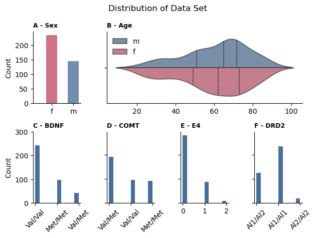

```python
fig = plt.figure()
gs = gridspec.GridSpec(2, 4)  # 2 rows, 2 columns grid

# Create subplots
ax1 = fig.add_subplot(gs[0, 0])
ax2 = fig.add_subplot(gs[0, 1:4]) # Right subplot, sharing y-axis with ax1
ax_1 = fig.add_subplot(gs[1, 0])
ax_2 = fig.add_subplot(gs[1, 1])
ax_3 = fig.add_subplot(gs[1, 2], sharey=ax_2)
ax_4 = fig.add_subplot(gs[1, 3], sharey=ax_2)

#Set main title
fig.suptitle("Distribution of Data Set")

#ax1 - plot
# Plot histogram for 'f' (female) with one color
ax1.hist(df_q1[df_q1["Sex"] == "f"]["Sex"], bins=2, color=plt.cm.inferno(0.5), alpha=0.7, align='left', label="Female")
# Plot histogram for 'm' (male) with a different color
ax1.hist(df_q1[df_q1["Sex"] == "m"]["Sex"], bins=2, color=plt.cm.viridis(0.3), alpha=0.7, align='left', label="Male")
#set axis labels and ticks
ax1.set_ylabel("Count")
set_axis(ax1, "A - Sex")

#ax2 - plot
# Create a violin plot for AgeCog_W1 with hue = Sex
sns.violinplot(data=df_q1, x="AgeCog_W1", ax=ax2, hue="Sex", split=True, inner="quart", palette=custom_palette, alpha=0.7)
set_axis(ax2, "B - Age")
#set axis labels
ax2.legend(frameon=False, loc='upper left')
ax2.set_xlabel(None)

#ax_1 - plot
ax_1.hist(data=df_q1, x="BDNFGenotype", align="mid", color= plt.cm.viridis(0.3), alpha=0.9)
##set axis limits and axis ticks
set_axis(ax_1, "C - BDNF")
ax_1.set_xticks(ax_1.get_xticks(), labels=ax_1.get_xticklabels(), rotation=45)
ax_1.set_yticks([0, 100, 200, 300])
ax_1.set_ylabel("Count")

#ax_2 - plot
ax_2.hist(data=df_q1, x="COMTGenotype", align="mid", color= plt.cm.viridis(0.3), alpha=0.9)
##set axis ticks
set_axis(ax_2, "D - COMT")
ax_2.set_xticks(ax_2.get_xticks(), labels=ax_2.get_xticklabels(), rotation=45)
ax_2.set_yticks([0,100,200,300])

#ax_3 - plot
ax_3.hist(data=df_q1, x="TotalE4Alleles", align="mid", color= plt.cm.viridis(0.3), alpha=0.9)
##set axis ticks
set_axis(ax_3, "E - E4")
ax_3.set_xticks([0,1,2])

#ax_4 - plot
ax_4.hist(df_q1["DRD2Genotype"].astype(str), align="mid", color= plt.cm.viridis(0.3), alpha=0.9)
##set axis ticks
set_axis(ax_4, "F - DRD2")
ax_4.set_xticks(ax_4.get_xticks(), labels=ax_4.get_xticklabels(), rotation=45)
ax_4.set_yticklabels([])  # Remove y-axis tick labels

plt.tight_layout()
plt.show()
```

```python
#calculate the descriptive statistics
summary_df_q1 = df_q1[["AgeCog_W1", "BMI_W1", "TotalE4Alleles"]].describe().round(2)
summary_df_q1
```

|  | AgeCog_W1 | BMI_W1 | TotalE4Alleles |
| --- | --- | --- | --- |
| count | 381.00 | 381.00 | 381.00 |
| mean | 59.93 | 25.89 | 0.28 |
| std | 17.33 | 3.87 | 0.50 |
| min | 21.00 | 17.16 | 0.00 |
| 25% | 50.00 | 23.05 | 0.00 |
| 50% | 63.00 | 25.72 | 0.00 |
| 75% | 72.00 | 28.34 | 1.00 |
| max | 89.00 | 36.71 | 2.00 |

## Analysis (Visualization and Test)

To accurately compare the distribution of genetic variants between sexes, it is important to account for the difference in sample sizes (as there are more women than men). Using absolute values would lead to misleading conclusions. To address this, the calculate_percentage function was created. This function computes the relative distribution of variants within each sex, and the resulting percentages are used in the visualization instead of absolute values.

```python
def calculate_percentage(df, x_variable, hue):
    """
    Calculates the relative distribution of the x_variable within each hue in a DataFrame.

    Parameters:
    - df (DataFrame): The DataFrame containing the data.
    - x_variable (str): The name of the column representing the variable to be analysed (e.g., "TotalE4Alleles").
    - hue (str): The name of the column representing the hue (e.g., "Sex").

    Returns:
    - prop_df: A DataFrame with the calculated proportions (prop).
    """
    prop_df = (df[x_variable]
               .groupby(df[hue])
               .value_counts(normalize=True)
               .rename("prop")
               .reset_index())

    return prop_df
```

### Allele Distribution by Sex

Question 1: What is the sex distribution among carriers of risk genes associated with Alzheimer's disease in the dataset?

**Visualization**

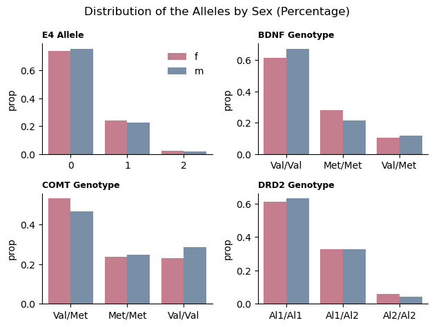

```python
fig, axs = plt.subplots(2,2)

#Set main title
fig.suptitle("Distribution of the Alleles by Sex (Percentage)")

#Plot E4
prop_E4 = calculate_percentage(df_q1,"TotalE4Alleles", "Sex")
sns.barplot(x="TotalE4Alleles", y="prop", hue="Sex", data=prop_E4,
            palette=custom_palette, alpha=0.7, ax=axs[0,0])
set_axis(axs[0,0], "E4 Allele")
axs[0,0].legend(frameon=False)

#Plot BDNF
prop_BDNF = calculate_percentage(df_q1,"BDNFGenotype", "Sex")
sns.barplot(x="BDNFGenotype", y="prop", hue="Sex", data=prop_BDNF,
            palette=custom_palette, alpha=0.7, ax=axs[0,1])
set_axis(axs[0,1], "BDNF Genotype")
axs[0,1].legend().set_visible(False)

#Plot COMT
prop_COMT = calculate_percentage(df_q1,"COMTGenotype", "Sex")
sns.barplot(x="COMTGenotype", y="prop", hue="Sex", data=prop_COMT,
            palette=custom_palette, alpha=0.7, ax=axs[1,0])
set_axis(axs[1,0], "COMT Genotype")
axs[1,0].legend().set_visible(False)

#Plot DRD2
prop_DRD2 = calculate_percentage(df_q1,"DRD2Genotype", "Sex")
sns.barplot(x="DRD2Genotype", y="prop", hue="Sex", data=prop_DRD2,
            palette=custom_palette, alpha=0.7, ax=axs[1,1])
set_axis(axs[1,1], "DRD2 Genotype")
axs[1,1].legend().set_visible(False)

for ax in axs.flatten():
    ax.set_xlabel(None)

plt.tight_layout()

plt.show()
```

This visualization does not show any significant differences between the sexes. To verify this hypothesis, a chi-square test is performed to assess the statistical significance of the observed differences. The chi-square test determines whether the distribution of categorical variables differs significantly from what would be expected by chance.

**Test**

```python
def chi_test(df, gene, hue):
    """
    Perform a Chi-square test of independence between two categorical variables.

    Parameters:
    df (pandas.DataFrame): The DataFrame containing the data.
    gene (str): The name of the column representing the gene tested.
    hue (str): The name of the column representing the categorical variable (eg.Sex)

    Returns:
    dict: A dictionary containing the results of the chi-square test.
    """
    # Create a contingency table
    contingency_table = pd.crosstab(df[hue], df[gene])

    # Perform the chi-square test
    chi2_stat, p_value, dof, expected = stats.chi2_contingency(contingency_table)

    # Return the test results in a dictionary
    return {"Gene": gene, "Chi2 Statistic": chi2_stat,
        "P-value": p_value, "Degrees of Freedom": dof
    }
```

```python
#list of the genes
genes = ["TotalE4Alleles", "BDNFGenotype", "COMTGenotype", "DRD2Genotype"]

#perform chi-square tests
results = []
for gene in genes:
    result = chi_test(df_q1, gene, "Sex")
    results.append(result)
# Convert the results into a DataFrame
results_table = pd.DataFrame(results)
results_table.set_index("Gene", inplace=True)
results_table
```

| Gene | Chi2 Statistic | P-value | Degrees of Freedom |
| --- | --- | --- | --- |
| TotalE4Alleles | 0.188833 | 0.909904 | 2 |
| BDNFGenotype | 2.228028 | 0.328239 | 2 |
| COMTGenotype | 2.001196 | 0.367660 | 2 |
| DRD2Genotype | 0.629977 | 0.729797 | 2 |

The chi-square test confirms the previously formulated hypothesis that the sex differences are not significant, as indicated by a p-value greater than 0.05.

### Amyloid Distribution by Sex and by Gene

Before addressing question 2, we aim to get an overview of the amyloid data and its relationship with both gene variants and sex.

**Visualization**

```python
# define function to plot each gene in its corresponding subplot
def boxplot_genes(gene, ax, title, hue=False):
    # Sample specific colors from a colormap
    cmap = cm.Blues
    custom_colors = [cmap(0.2), cmap(0.5), cmap(0.8)]

    if hue==True:
        sns.boxplot(
            data=df_q2,
            x=gene,
            y="GlobalSUVR",
            hue="Wave",
            palette=custom_colors,
            ax=ax
        )
    else:
         sns.boxplot(
            data=df_q2,
            x=gene,
            y="GlobalSUVR",
            color= plt.cm.viridis(0.3),
            showfliers=False,
            ax=ax
        )

    set_axis(ax, title)
    ax.set_xlabel(None)
    ax.set_ylabel("Global SUVR")
```

```python
#calculate the mean for each participant across the three waves
df_q2_grouped = df_q2.groupby(["S#","Sex"])["GlobalSUVR"].mean()
df_q2_grouped= pd.DataFrame(df_q2_grouped)
df_q2_grouped = df_q2_grouped.reset_index()

#calculate mean female and male
mean_value_m= df_q2_grouped[df_q2_grouped["Sex"]=="m"]["GlobalSUVR"].mean()
mean_value_f= df_q2_grouped[df_q2_grouped["Sex"]=="f"]["GlobalSUVR"].mean()
```

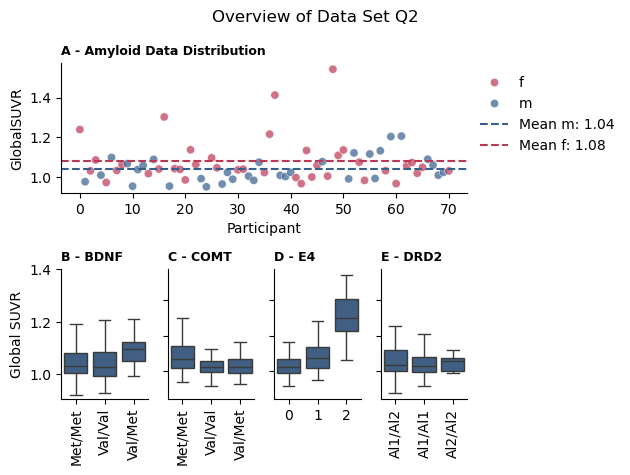

```python
#define Grid
fig = plt.figure()
gs = gridspec.GridSpec(2, 4)  # 2 rows, 2 columns grid

#set main title
fig.suptitle("Overview of Data Set Q2")

#create subplots
ax1 = fig.add_subplot(gs[0, 0:4])

ax_1 = fig.add_subplot(gs[1, 0])
ax_2 = fig.add_subplot(gs[1, 1])
ax_3 = fig.add_subplot(gs[1, 2], sharey=ax_2)
ax_4 = fig.add_subplot(gs[1, 3], sharey=ax_2)

#ax1 - plot
#create scatterplot
sns.scatterplot(data=df_q2_grouped, x=df_q2_grouped.index, y="GlobalSUVR", hue="Sex", palette=custom_palette, alpha=0.7, ax=ax1)
ax1.axhline(mean_value_m, color=plt.cm.viridis(0.3), linestyle='--', label=f"Mean m: {mean_value_m:.2f}")
ax1.axhline(mean_value_f, color=plt.cm.inferno(0.5), linestyle='--', label=f"Mean f: {mean_value_f:.2f}")
# Move the legend outside the plot
ax1.legend(frameon=False, loc='upper left', bbox_to_anchor=(1, 1))
ax1.set_xlabel("Participant")
set_axis(ax1, "A - Amyloid Data Distribution")

#create boxplots
boxplot_genes("BDNFGenotype", ax_1, "B - BDNF")
boxplot_genes("COMTGenotype", ax_2, "C - COMT")
boxplot_genes("DRD2Genotype", ax_4, "E - DRD2")
boxplot_genes("TotalE4Alleles", ax_3, "D - E4")

#ax_1 - plot
ax_1.set_xticks(ax_1.get_xticks(), labels=ax_1.get_xticklabels(), rotation=90)
ax_1.set_yticks([1.0,1.2,1.4])

#ax_2 - plot
ax_2.set_xticks(ax_2.get_xticks(), labels=ax_2.get_xticklabels(), rotation=90)
ax_2.set_yticks([1.0,1.2,1.4])
ax_2.set_ylabel(None)

#ax_3 - plot
ax_3.set_xticks([0,1,2])
ax_3.set_yticks([1.0,1.2,1.4])
ax_3.set_ylabel(None)

#ax_4 - plot
ax_4.set_xticks(ax_4.get_xticks(), labels=ax_4.get_xticklabels(), rotation=90)
ax_4.set_yticks([1.0,1.2,1.4], labels=[])
ax_4.set_ylabel(None)

plt.tight_layout()
plt.show()
```

```python
#calculate the descriptive statistics
summary_df_q2 = df_q2[["GlobalSUVR"]].describe().round(2)
summary_df_q2
```

|  | GlobalSUVR |
| --- | --- |
| count | 213.00 |
| mean | 1.06 |
| std | 0.11 |
| min | 0.88 |
| 25% | 1.00 |
| 50% | 1.03 |
| 75% | 1.09 |
| max | 1.65 |

We can see in A a few patients with remarkably higher amyloid levels. Notably, all of them are women. These patients stand out from the group, but we decided not to treat them as outliers because their values are still within a plausible range. While there is no consensus on optimal thresholds for SUVR classification, we utilized a cutoff of 1.55, as proposed by Therriault et al. [12].

The BDNF and particularly the APOE genes show a higher amyloid level for their risk variants. We also observe that the mean amyloid level is slightly higher for females than for males. To determine if this difference is statistically significant, we performed an independent samples t-test, comparing the means of the two groups.

**Test**

```python
general_f = df_q2_grouped[(df_q2_grouped["Sex"] == "f")]["GlobalSUVR"]
general_m = df_q2_grouped[(df_q2_grouped["Sex"] == "m")]["GlobalSUVR"]
t,p = stats.ttest_ind(general_f, general_m, equal_var=False)

print(f"T-statistic: {t}, p-value: {p}")
```

```
T-statistic: 1.8186770642414447, p-value: 0.07380314590369806
```

The result of the t-test shows that there is no significant difference between the mean amyloid data for women and men. The p-value is relatively low, but it is not below 0.05, the usual significance threshold.

### Amyloid Distribution by Gene for each wave

Question 2: How do different genetic variants correlate to Amyloid data?

The purpose of the following visualization is to compare the amyloid distribution between the first and third waves for each variant of the genes. Since amyloid is a well-established predictor for Alzheimer's disease, this comparison provides valuable insights into the potential progression of AD in patients with specific genetic variants.

**Visualization**

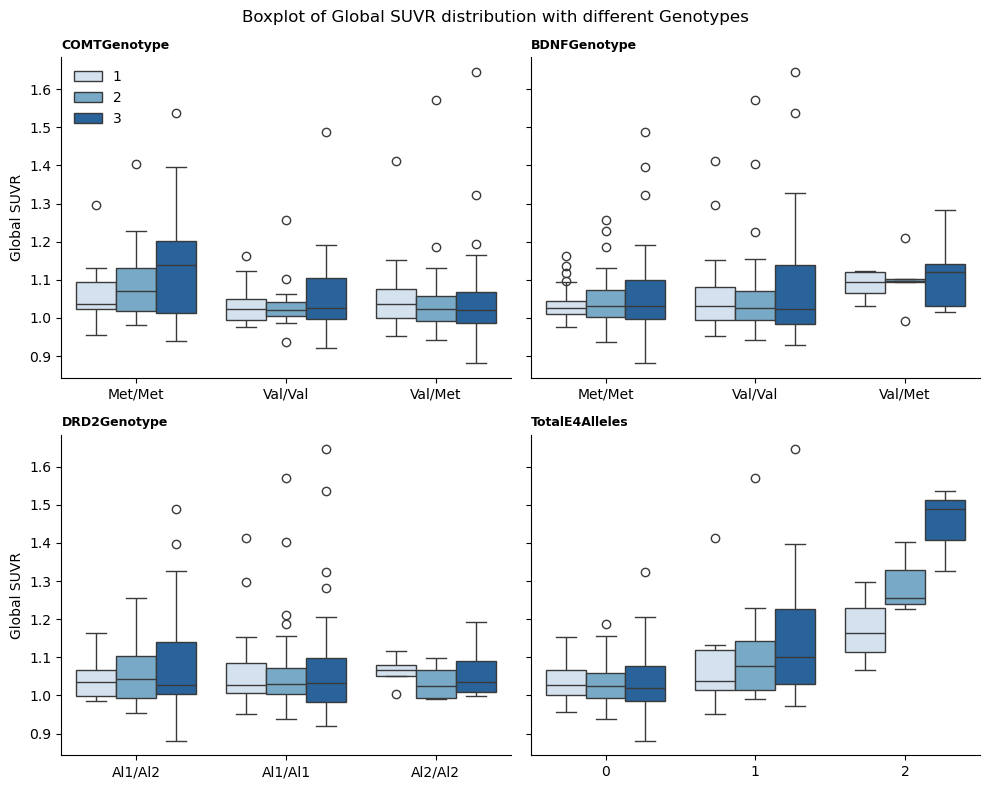

```python
#create a 2x2 grid of subplots
fig, axes = plt.subplots(2, 2, figsize=(10,8), sharey=True)  # Adjust figure size as needed

boxplot_genes("COMTGenotype", axes[0,0], "COMTGenotype", True)
boxplot_genes("BDNFGenotype", axes[0,1], "BDNFGenotype", True)
boxplot_genes("DRD2Genotype", axes[1,0], "DRD2Genotype", True)
boxplot_genes("TotalE4Alleles", axes[1,1], "TotalE4Alleles", True)

#adjust layout and show plot
fig.suptitle("Boxplot of Global SUVR distribution with different Genotypes")

#wave legend only in axes[0,0]
axes[0,0].legend(frameon=False)
axes[0,1].legend().set_visible(False)
axes[1,0].legend().set_visible(False)
axes[1,1].legend().set_visible(False)

plt.tight_layout()
plt.show()
```

We observe a correlation between amyloid increase and the Met/Met variant of the COMT gene, as well as the APOE gene with both alleles mutated (TotalE4Alleles equal to 2), as indicated by the large median differences between wave 1 and wave 3. We test the significance of the median differences for each risk variant using a t-test.

**Test**

```python
def t_test(gene, risk):
    """
    Calculate a t-test the globalSUVR value in wave 1 and wave 3.
    """
    w1 = df_q2[(df_q2[gene] == risk) & (df_q2["Wave"] == 1)]["GlobalSUVR"]
    w3 = df_q2[(df_q2[gene] == risk) & (df_q2["Wave"] == 3)]["GlobalSUVR"]
    t,p = stats.ttest_rel(w1, w3)

    # Return the test results in a dictionary
    return {"Gene": gene, "T-value": t, "P-value": p}
```

```python
#perform t-tests
test = []
test.append(t_test("COMTGenotype", "Met/Met"))
test.append(t_test("BDNFGenotype", "Met/Met"))
test.append(t_test("DRD2Genotype", "Al1/Al1"))
test.append(t_test("TotalE4Alleles", 2))

# Convert the results into a DataFrame
test_table = pd.DataFrame(test)
test_table.set_index("Gene", inplace=True)
test_table
```

| Gene | T-value | P-value |
| --- | --- | --- |
| COMTGenotype | -2.966417 | 0.007128 |
| BDNFGenotype | -1.619549 | 0.118961 |
| DRD2Genotype | -1.437441 | 0.157510 |
| TotalE4Alleles | -10.710125 | 0.008606 |

The p-values from the t-tests confirm the observations from the visualization, showing a significant difference in the medians between wave 1 and wave 3 for the risk variants of the COMT and APOE genes.

### Risk categories

**Define risk category dependant of number of allele mutations**

```python
def define_risk(df, column_old, column_new, moderate, high):
    """
    Adds a new column to the given DataFrame, categorizing the values of an existing column into numeric risk levels.
    The new column is inserted immediately after the source column.

    Parameters:
    df : DataFrame
        The input DataFrame to which the new column will be added.
    column_old : str
        The name of the existing column in the DataFrame that contains the categorical risk levels to be mapped.
    column_new : str
        The name of the new column to be added to the DataFrame. This column will contain the numeric risk levels.
    moderate : str
        The category from `column_old` that represents a "moderate" level of risk.
    high : str
        The category from `column_old` that represents a "high" level of risk.
    Returns: None
    """
    position = df.columns.get_loc(column_old)+1
    risk_mapping = {high: 2, moderate: 1}
    new_column = df[column_old].map(risk_mapping).fillna(0).astype(int)
    df.insert(position, column_new, new_column)
```

```python
#Categorize the mutations into risk levels (0,1,2)
define_risk(df_q2, "BDNFGenotype", "BDNFAlleles", "Val/Met", "Met/Met")
define_risk(df_q2, "COMTGenotype", "COMTAlleles", "Val/Met", "Met/Met")
define_risk(df_q2, "DRD2Genotype", "DRD2Alleles", "Al1/Al2", "Al1/Al1")
```

**Define risk level (low, medium, high)**

```python
#sum the risk levels
df_q2["Risk_level"] = (df_q2["TotalE4Alleles"] + df_q2["DRD2Alleles"])

# Define a function for the risk category
def categorize_risk(level):
    if level > 2:
        return "High"
    elif level == 2:
        return "Medium"
    else:
        return "Low"

# Apply the function to create the new column
df_q2["Risk_category"] = df_q2["Risk_level"].apply(categorize_risk)
```

**Visualization of the risk category distribution**

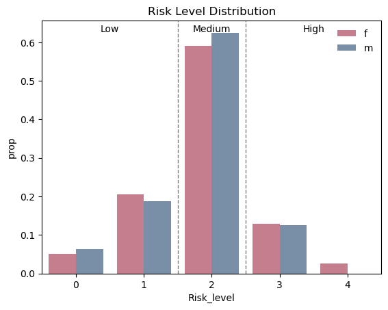

```python
fig, axs = plt.subplots()
prop_level = calculate_percentage(df_q2, "Risk_level", "Sex")
sns.barplot(x="Risk_level", y="prop", hue="Sex", data=prop_level,
            palette=custom_palette, alpha=0.7, ax=axs)

# Add vertical lines to separate the plot into risk categories
axs.axvline(x=1.5, color="gray", linestyle="--", linewidth=1)
axs.axvline(x=2.5, color="gray", linestyle="--", linewidth=1)

# Add labels for the risk categories
axs.text(0.5, axs.get_ylim()[1] * 0.955, "Low", ha="center", fontsize=10)
axs.text(2, axs.get_ylim()[1] * 0.955, "Medium", ha="center", fontsize=10)
axs.text(3.5, axs.get_ylim()[1] * 0.955, "High", ha="center", fontsize=10)

axs.set_title("Risk Level Distribution")
axs.legend(frameon=False)
plt.show()
```

### Amyloid Distribution by Risk Level and Sex

Question 3: How does amyloid distribution differ by sex across varying levels of genetic risk?

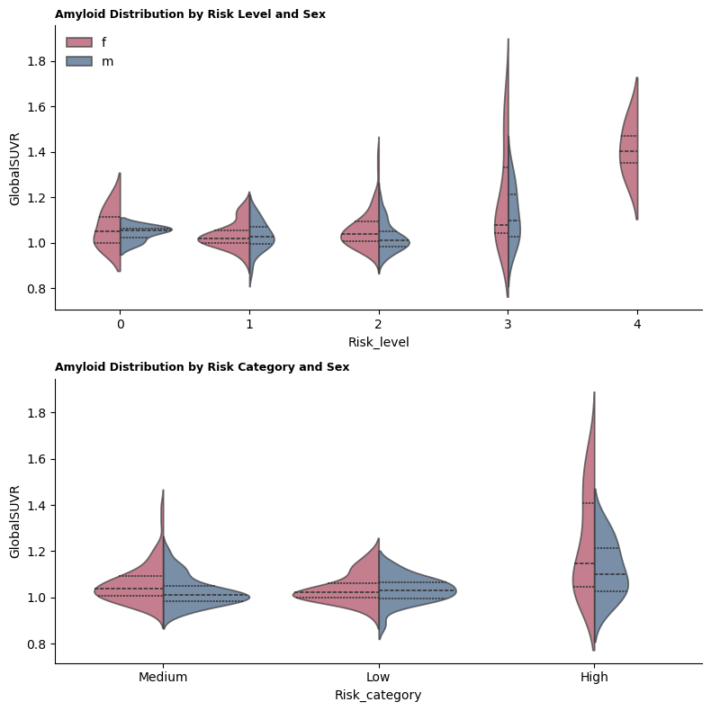

```python
#Plot the relationship between Amyloid and risk
fig, axs = plt.subplots(2, figsize=(8,8))

#Risk level
sns.violinplot(data=df_q2, x="Risk_level", y="GlobalSUVR", hue="Sex",
              split=True, inner="quart", palette=custom_palette, alpha=0.7, ax=axs[0])
set_axis(axs[0], "Amyloid Distribution by Risk Level and Sex")
axs[0].legend(frameon=False, loc='upper left')

#Risk category
sns.violinplot(data=df_q2, x="Risk_category", y="GlobalSUVR", hue="Sex",
              split=True, inner="quart", palette=custom_palette, alpha=0.7, ax=axs[1])
set_axis(axs[1], "Amyloid Distribution by Risk Category and Sex")
axs[1].legend_.remove()

plt.tight_layout()
plt.show()
```

Although the global SUVR is slightly higher in the high-risk category, the difference does not appear to be significant.

## Conclusion

- What is the sex distribution among carriers of risk genes associated with Alzheimer's disease in the dataset?

The distribution of the risk alleles by sex is not significantly different in the observed dataset.

- How do different genetic variants correlate to Amyloid data?

Significant correlations between the mean Global SUVR between wave 1 and wave 3 was shown for high risiko alleles of the COMT and APOE gene. This indicates that there is a correlation of these genetic variants with the amyloid distribution.

- How does amyloid distribution differ by sex across varying levels of genetic risk?

The data revealed that high amyloid levels were predominantly observed in women. However, the number of participants in the high-amyloid group was insufficient to draw statistically significant conclusions.

## Limitations

The dataset contained a higher proportion of female participants compared to males, which could introduce bias and lead to potential misinterpretations if the data is not normalized to account for the overall sample size.

Additionally, this project focused solely on global SUVR, despite evidence suggesting that amyloid distribution can vary across different brain regions.

Moreover, insufficient amyloid data was available for patients across all three waves, resulting in a limited sample size that may restrict the ability to draw statistically significant conclusions.

## Contributions

- Maée: Description of all plots, Risk Category Analysis, Distribution of Alleles by Sex, Layout(Code Cleaning)
- Nerea: Introduction, Conclusion, Limitations, Data overview, Global SUVR Distribution
- Together: Data read-in, Preprocessing, Fusion of Datasets, Discussion of all Major Steps

## References

[1] A. Kumar, A. Singh, and Ekavali, “A review on Alzheimer’s disease pathophysiology and its management: an update,” Pharmacological Reports, vol. 67, no. 2, pp. 195–203, Apr. 2015, doi: 10.1016/J.PHAREP.2014.09.004.

[2] T. R. Hunter, L. E. Santos, F. Tovar-Moll, and F. G. De Felice, “Alzheimer’s disease biomarkers and their current use in clinical research and practice,” Molecular Psychiatry 2024, pp. 1–13, Sep. 2024, doi: 10.1038/s41380-024-02709-z.

[3] G. B. Frisoni et al., “The probabilistic model of Alzheimer disease: the amyloid hypothesis revised,” Nature Reviews Neuroscience 2021 23:1, vol. 23, no. 1, pp. 53–66, Nov. 2021, doi: 10.1038/s41583-021-00533-w.

[4] “Alzheimer’s Disease Genetics Fact Sheet | National Institute on Aging.” Accessed: Nov. 27, 2024. [Online]. Available: https://www.nia.nih.gov/health/alzheimers-causes-and-risk-factors/alzheimers-disease-genetics-fact-sheet

[5] S. Miramontes et al., “Alzheimer’s disease as a women’s health challenge: a call for action on integrative precision medicine approaches,” npj Women’s Health 2024 2:1, vol. 2, no. 1, pp. 1–5, May 2024, doi: 10.1038/s44294-024-00021-3.

[6] M. Patel, “Revising the risk of Alzheimer disease in women,” Nature Reviews Neurology 2017 13:10, vol. 13, no. 10, pp. 575–575, Sep. 2017, doi: 10.1038/nrneurol.2017.130.

[7] A. Serretti and P. Olgiati, “Catechol-o-methyltransferase and Alzheimer’s disease: a review of biological and genetic findings,” CNS Neurol Disord Drug Targets, vol. 11, no. 3, pp. 299–305, Oct. 2012, doi: 10.2174/187152712800672472.

[8] M. N. Perkovic, D. S. Strac, L. Tudor, M. Konjevod, G. N. Erjavec, and N. Pivac, “Catechol-O-methyltransferase, Cognition and Alzheimer’s Disease,” Curr Alzheimer Res, vol. 15, no. 5, pp. 408–419, Dec. 2018, doi: 10.2174/1567205015666171212094229.

[9] N. Franzmeier et al., “The BDNFVal66Met SNP modulates the association between beta-amyloid and hippocampal disconnection in Alzheimer’s disease,” Molecular Psychiatry 2019 26:2, vol. 26, no. 2, pp. 614–628, Mar. 2019, doi: 10.1038/s41380-019-0404-6.

[10] K. Blum et al., “The DRD2 Taq1A A1 Allele May Magnify the Risk of Alzheimer’s in Aging African-Americans,” Mol Neurobiol, vol. 55, no. 7, pp. 5526–5536, Jul. 2018, doi: 10.1007/S12035-017-0758-1.

[11] S. Bullich et al., “Early detection of amyloid load using 18F-florbetaben PET,” Alzheimers Res Ther, vol. 13, no. 1, pp. 1–15, Dec. 2021, doi: 10.1186/S13195-021-00807-6/FIGURES/7.

[12] J. Therriault et al., “Determining Amyloid-β Positivity Using 18F-AZD4694 PET Imaging,” J Nucl Med, vol. 62, no. 2, pp. 247–252, Feb. 2021, doi: 10.2967/JNUMED.120.245209.

[13] R. Ossenkoppele et al., “Accuracy of Tau Positron Emission Tomography as a Prognostic Marker in Preclinical and Prodromal Alzheimer Disease: A Head-to-Head Comparison Against Amyloid Positron Emission Tomography and Magnetic Resonance Imaging,” JAMA Neurol, vol. 78, no. 8, pp. 961–971, Aug. 2021, doi: 10.1001/JAMANEUROL.2021.1858.